# STAT 240 Introduction

## Outline

1. Introduction
2. STAT 240 and the data science major and certificate
3. Syllabus overview
4. Online textbook
5. Online course notes
6. Discord
7. R and R Studio
8. A sneak preview of our first case study

## Introductions

- Professor XXX
- TA XXX
- TA XXX

## STAT 240

- Introductory data science course
  - Relatively new course first taught in Fall 2019
  - Does not assume previous computing or statistics
    - (But we start ramping up the computing right away!)
  - Data science from a statistical point of view
  - Required course for the data science major
    - major began in Fall 2020
    - first graduates in December 2021
    - about 1150 students declared in the major prior last semester
    - fastest growing major on campus
  - Satisfies foundational data science requirement for the data science certificate

## Syllabus Overview

- Course components
  - Discussion Assignments:
    - bring a laptop
    - typically a group assignment (first one is individual)
    - assigned groups (groups change midway through the semester)
    - most or all work intended to be completed in person
    - TA gives a brief overview, then work with group to complete
    - only one group member turns in the assignment
    - **must be present and working with group to receive credit**
    - *exceptions possible if ill and isolating* (Zoom or other)
  - Individual Assignments:
    - longer assignments than discussion
    - typically due Friday evenings at 11:59pm
    - solve problems similar to those presented in lecture
  - Final Project:
    - A group assignment in the last half of the course
    - Final product:
      - a report
    - Students pick their own data set, pose questions, and address them with a suitable data analysis
  - Exams:
    - Midterm exam is during lecture
      - may also contain a take-home computer-based portion
    - Final exam is in-person two-hour exam

## Online textbook

- *R for Data Science* by Hadley Wickham and Garret Grolemund
  - Hadley Wickham is the mastermind behind the tidyverse expansion to the R universe which is the center of our course
  - Free online textbook
  - https://r4ds.had.co.nz/

## Online course notes

- *Statistics 240 Course Notes and Case Studies*
  - online notes for the course
  - still under development

## Discord

- A social platform to exchange text messages and other media
- A place to ask content questions about the course
  - general questions
  - questions about assignments
  - you may register with your own name or an anonymous one
- All instructors and TAs will contribute to responses
- Students also encouraged to respond
- There are different conversations for each lecture/assignment and different threads for each problem
- Read the appropriate thread before asking in case a similar question has already been asked!
- Only use email for personal questions:
  - disability accommodations
  - illness notifications
  - grading clarifications
  - personal requests

## R and R Studio

- Follow instructions in the course notes to install on your computer
- Install R, but do not work with it directly
- R Studio will be our primary interface for
  - writing code
  - managing files and directories
  - running R
  - producing reports

## Lake Mendota

- Case studies for some photos and background
- Sample steps of a data analysis
  1. Obtain data from the web into a suitable form to read into R
     - This data set required a fair amount of manual editing
  2. Read in the data and check for accuracy
  3. Consider interesting questions to ask
  4. Wrangle the data set into a desired form
  5. Explore with graphs and data summaries
  6. Consider models to explain trends or differences
  7. Iterate steps 3-6 as desired
  8. Summarize findings in a report

> How has the duration that Lake Mendota is closed by ice (at least 50% covered by ice) changed over time?

### Block of code to load required libraries

- We will create files with:
  - code to carry out data analysis
  - words to explain and interpret what we have done
- An initial code chunk will typically load in one or more packages from the “tidyverse”, a collection of extensions to the R language which work well together and help us to do many typical data science tasks

```r
## Load in the core tidyverse packages
##  - including ggplot2 for graphics;
##  - and dplyr for data calculations
library(tidyverse)
library(lubridate)
```

### Read and explore data

- The function `read_csv()` reads data into an R session from a CSV (comma separated variable) file.
- This code creates an object in the session named `mendota` with the data from Lake Mendota freeze durations going back over 160 years.
  - The name in the quotes is a *path* through the directory structure to the file which contains the data

```r
mendota = read_csv("../../data/lake-mendota-winters-2022.csv")
```

### Create a graph to examine the question

- This code chunk creates a graph.
- Think of building a graph as adding on additional layers
  - Each step adds something new or modifies something there before
- This code may look intimidating at first glance, but you will be writing code similar to this next week!

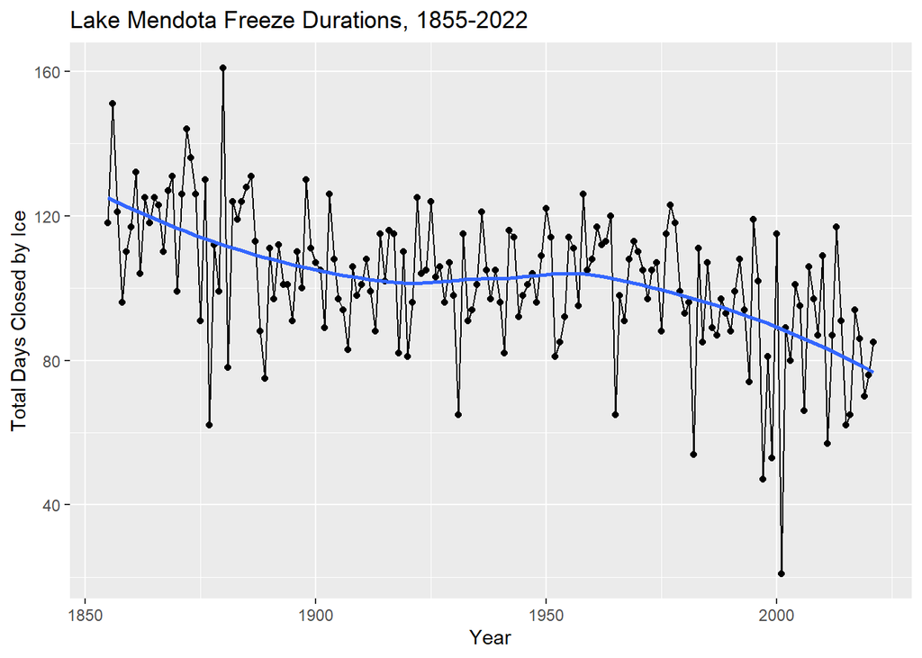

```r
ggplot(mendota, aes(x=year1, y=duration)) +
  geom_point() +
  geom_line() +
  geom_smooth(se=FALSE) +
  xlab("Year") +
  ylab("Total Days Closed by Ice") +
  ggtitle("Lake Mendota Freeze Durations, 1855-2022")
```

### Observations

- There is a decreasing trend in the duration that Lake Mendota is frozen over time
  - In 1855, in a typical winter, Lake Mendota was frozen for over 120 days
  - In recent times, Lake Mendota is frozen for under 80 days in a typical winter
- The trend does not appear to be fully linear
  - It appears that there was a decrease from the mid 1850s until about 1900
  - There was little change in the trend from about 1900 until about 1960
  - Since 1960, there has been a decreasing trend again, perhaps at a faster rate than the earlier decrease from 1850 - 1900.
- There is considerable year-to-year variation
  - In any given year, the actual duration time of Lake Mendota being closed by ice may differ from the trend line by a few weeks
  - A two week difference is typical, but there are examples where the difference exceeds this substantially
- The trend line may be interpreted as a **change in climate**
- The oscillations around the trend line may be interpreted as random effects due to annual variations in the **weather**.
- In a statistical model of this data, we may explain what we see as a central trend over time with some random noisy variation in what actually occurs each year.

#### Follow-up questions

1. Are there changes to the typical dates that Lake Mendota first freezes in the winter and finally thaws in the spring?
2. Can we predict the thaw date based on the date the lake first freezes?
3. Can we predict the total duration that the lake will be frozen in the upcoming winter?
4. Is the model for the trend appropriate? Would a simpler straight-line model be adequate?
5. Can we characterize the distribution of variation around the trend line?
6. Is the rate of decrease in the total freeze duration larger now than it was between 1850 and 1900?

### Next Tasks

- Follow the course notes to:
  - install R
  - install R Studio
  - install the tidyverse packages
- Bring your laptop to class on Friday
  - ideally, you will have the software installed
  - if you have trouble, you will have a chance to ask for help:
    - in office hours
    - in the Statistics Learning Center
    - in discussion next week
- Complete the student survey
- Read the first few chapters of the course notes and complete online quizzes
- See the course web page for initial assignments about the course set-up

## Preparation

- It will be very helpful to read *CNCS* (Course Notes and Case Studies) [chapter 2](https://bookdown.org/bret_larget/stat-240-case-studies/prerequisites.html) and [chapter 5](https://bookdown.org/bret_larget/stat-240-case-studies/r-fundamentals.html) prior to this lecture.

## Aims

- At the end of the lecture, you should know:
  - How to navigate within R Studio
  - How to manage files and directories
  - How to distinguish between the active session and knitting
  - Key parts of an R Markdown document
  - How to install and load a package
  - How to create, manipulate, and calculate with vectors in R
  - What a data frame is
  - How to access help

## Outline

1. Installing R and R Studio
2. Browser settings
3. Setting up course directories
4. Paths and special symbols
5. Working Directory
6. Interactive execution versus knitting
   - concept of a *session*
7. Parts of an R Markdown document
8. Packages
   - installing versus loading
9. Console versus R Markdown file
10. Vectors
    - assignment
    - object names
    - arithmetic
    - common functions
    - data types
11. Data frames
    - dimensions
    - extracting variables
12. Using help

## Installing R and R Studio

- Live demonstration on how to download R and R Studio
  - [R](https://cran.r-project.org/)
  - [R Studio](https://www.rstudio.com/)

## Browser settings

- Live demonstration of changing Chrome settings

## Setting up course directories

- Live demonstration of creating course directories
  - `COURSE/`
  - `COURSE/data/`
  - `COURSE/hw/`
  - `COURSE/lecture/`
  - `COURSE/scripts/`
  - `COURSE/discussion/`
- Download:
  - the example R Markdown file `02-examples.Rmd` to the `lecture` directory
  - the data set `lake-mendota-winters-2021.csv` to the data directory

## Paths and special symbols

### Paths

- A *path* is a string (sequence of characters) which represents a location (directory) or a file in a computer’s file system
  - An *absolute path* begins at the root of the file system
  - Recognize an absolute path beginning with a slash (`/`)
  - Example: `/Users/larget/Documents/stat240/`
    - *Note*: On Windows computers, paths are specified using back-slashes (`\`) instead of slashes.
    - However, the `\` symbol carries special meaning inside of R.
    - R will handle using `/` for any operating system
    - **Always** use `/` in R in paths after a directory name so your code will be reproducible on any computer operating system
  - A *relative path* does not begin with a `/` and instead, specifies a path relative to the *current working directory*.
  - Examples:
    - `~/Documents/stat240/`
    - `../../data/lake-mendota-winters-2021.csv`
    - `./lectures/`
    - `02-examples.Rmd`
  - Inside of R, put quotes (typically double, `"`, but single `'` works too) around the string that represent the path

### Example

```r
mendota = read_csv("../../data/lake-mendota-winters-2021.csv")
```

### Special Symbols

- The tilde symbol `~` represents the *home directory*.
  - On my Mac, this is `/Users/larget/`
  - On your Mac, it is /Users/your-user-name/`- (If this is also`/Users/larget/`, you are either my relative or strange.)
  - On a Windows computer, the home directory is `Documents`.
  - In the File manager in R Studio, this directory is labeled as `Home`.
- The period character `.` represents the current directory.
- A double period `..` is the *parent directory*.
  - The parent directory is the one which directly contains another directory or file

## Working Directory

- R has a notion of a *working directory*.
- When the working directory is set, relative paths begin there instead of at the root.

### Example

- If I set my working directory to be `~/Documents/stat240/lecture/`, a path to the data file in `~/Documents/stat240/data/data-file.csv` may be referenced with the path `../data/data-file.csv`.
  - `../` says navigate to the parent directory which is `~/Documents/stat240/`
  - `data/` says navigate to its sub-directory with the name `data`
  - the file-name is next.
- By default, the working directory is set to be `Home` when you begin an interactive R session.
- You will typically navigate to the directory which contains an R Markdown (.Rmd or .rmd) file and set it to be the working directory for an analysis.

## Interactive execution versus knitting

- When we begin an R session inside of R Studio, assuming we are not starting from a previous saved session, then:
  - the working directory is `Home`
  - the environment is empty
  - you need to set the working directory

> A very common error among beginners is to navigate to the directory with an R Markdown file, open the file, and try executing the code within. The error occurs, for example, when running code with a relative path that assumes the working directory is the directory which holds the file, when the working directory is still `Home`. The path does not lead to the location of the desired file, and the command to read the file’s data fails.
- In contrast, when knitting a document, the directory that holds the file is set to be the working directory automatically.
  - However, when knitting, a new clean and empty R environment is opened before any code is executed.
  - So, for example, if you loaded the **tidyverse** library interactively, but do not have a code chunk in the file to do the same, then code from this package will not be recognized, causing an error.
  - Similarly, objects in the environment that were created by interactively will not be present when the document is knitted.

> A common error for beginners when trying to knit a document is to fail because the document assumes that a library has been loaded or that an object exists in the environment, but the knitted document does not load the missing library or create the missing object

## Parts of an R Markdown document

### See the example file

- An R Markdown file is separated into parts of three different types
  1. The YAML section (a preamble to set some parameters)
  2. R code chunks (sections of R code with arguments to set options about execution and what to display in the knitted document)
  3. Markdown language (simple text with words and limited control over formatting)
- The file begins with the YAML section
- R code chunks and Markdown sections may be interspersed
- It is also possible to include small inline elements of R code within the Markdown sections.

### YAML

- The YAML section is at the beginning of the file
- The acronym YAML is a pun, as the Y is self-referencing and stands for the entire acronym YAML
- The full acronym is “YAML ain’t markdown language”
- The YAML section is at the start of the file and begins and ends with three dashes, `---` alone on a line
- Our YAML section will typically be very simple and do nothing more than specify that the output file format after knitting should be HTML.

```
---
output: html_document
---
```

- Sometimes we will include other code in the YAML section, such as an title, author, and date, for the creation of a title page to the document
- Think of the YAML section as a prefix to the file
- The point about *YAML ain’t markdown language* is that the special interpretations of characters (to make bullet lists, boldface font, and so on) do not work within the YAML section.

### R chunks

- A chunk of R code within an R Markdown file begins with three single back ticks followed by an open brace, the letter `r`, an optional space and name for the code chunk, and then optional arguments for knitting separated by commas before an end brace.
- The chunk ends with three single back ticks alone on a line
- It is good practice to leave a blank line before and after each code chunk
  - This treats each code chunk as a separate “paragraph”.
  - If the code produces a graph, you may have text starting to the right of the plot instead of on a separate line below the plot in the knitted document if you do not leave a blank line after the code chunk.

#### Examples

- A minimal example

````markdown
```{r}
# some code here
```
````

- A named R code chunk

````
```{r chunk-name}
# more code here
```
````

- An R chunk with an argument to not include the code or the output in the knitted document

````markdown
```{r include = FALSE} ``
# some code
```
````

- A named R chunk that specifies the height and width of the figure in inches and suppresses the code to make the graph.

````markdown
```{r example-chunk-name, echo = FALSE, fig.height = 3, fig.width = 6}
# code to make the plot
```
````

### Markdown

- Markdown is a simplified way to code formatting in documents that are easy for people to read and write.
- A *Markup* language, in contrast, such as HTML (Hyper Text Markup Language) or LaTeX, is substantially more complicated and richer and allows for much more fine control of the formatted output.
- Learn Markdown by editing example files we provide.
- A few basics:
  - Use hashes `#` to create headers.
    - A single `#` is a very large header
    - The more hashes (`####`, for example), the smaller the header is.
- Use dashes (`-`, or `*` or `+` if you prefer) for bullet lists
- Indent four spaces for a sub-list.
- If you use numbers instead of dashes, you get a numbered list.
- Put single asterisks around a word or phrase for *italics*.
- Put double asterisks around the same for **bold face**.
- See the R Markdown cheatsheet for a quick reference.

## Console versus R Markdown file

- You can run R interactively by typing into the console.
- It is better to write and edit R code into an R Markdown file.
- This leads to keeping a reproducible history of your work that you can share with others and with your future work.
- I occasionally type something quick into the Console for a one-off calculation I do not need to save, but any work on an assignment or project or anything even slightly complicated is best done by writing code in a file and then executing that code.

## Vectors

- A vector is sequence of objects that all have the same type (such as a vector of integers, or double precision numbers, or character strings).
- There are many ways to create and manipulate vectors in R.
- In the tidyverse, we generally will work with vectors only as columns in data frames, but it helps to understand how base R vectors work first before moving on to data frames.
- The file `02-examples.Rmd` will have many examples to work through interactively.